# Tidybiology Final Project

Ava Mackay-Smith

November 06, 2023

# Description of Project

I want to use a method developed in humans and mice in butterflies, but I don’t know that the assay will work because the butterfly genome has a different G/C content than humans and mice, and the assay uses a set of restriction enzymes whose recognition sites might be affected by different genome contents.

# Analysis Goal

I want to make sure that using the assay’s restriction enzymes will function as expected in the butterfly genome to produce sequenceable sizes - with the majority not over 400bp, but also not under 20bp, since I can’t reliably recover that fragment size. I need to ensure that the fragment pattern is the same between the butterfly and mouse genomes. There is a second version of the protocol that uses slightly different restriction enzymes that I will also investigate.

## Import data

```r
#using the diffHic package, perform an in silico digest of the butterfly and mouse genomes, using both the version 1 and version 2 enzymes.
#butterfly
hmm_v1_cuts <- cutGenome("/Users/macgyver/Desktop/wray - raw data/H-melpomene_genomes/Heliconius_melpomene_-_scaffolds.fa", c("GTAC", "CATG", "GTTTAAAC"), overhang=c(2L, 4L, 0L))
hmm_v2_cuts <- cutGenome("/Users/macgyver/Desktop/wray - raw data/H-melpomene_genomes/Heliconius_melpomene_-_scaffolds.fa", c("TTAA", "CATG"), overhang=c(2L, 4L))
#mouse
m39_v1_cuts <- cutGenome("/Users/macgyver/Desktop/wray - raw data/mouse_genome/m39_unmasked.fna", c("GTAC", "CATG", "GTTTAAAC"), overhang=c(2L, 4L, 0L))
#make v2 cuts
m39_v2_cuts <- cutGenome("/Users/macgyver/Desktop/wray - raw data/mouse_genome/m39_unmasked.fna", c("TTAA", "CATG"), overhang=c(2L, 4L, 0L))
```

## Exploratory analysis

Part 1. Rearrange imported data into one table per organism with the in silico digest fragment lengths in columns corresponding to the protocol used, and examine the distribution of those fragments.

```r
#create tibbles of both protocols
widths_hmm <- as_tibble(cbind(hmm_v1_cuts@ranges@width, hmm_v2_cuts@ranges@width))
colnames(widths_hmm) <- c("Hmm_v1_protocol", "Hmm_v2_protocol")
widths_m39 <- as_tibble(cbind(m39_v1_cuts@ranges@width, m39_v2_cuts@ranges@width))
colnames(widths_m39) <- c("m39_v1_protocol", "m39_v2_protocol")

#Generate summary statistics for those fragment lengths
summary(widths_m39)
```

```
##  m39_v1_protocol   m39_v2_protocol
##  Min.   :      5   Min.   :      4
##  1st Qu.:     40   1st Qu.:     28
##  Median :     96   Median :     62
##  Mean   :    150   Mean   :     99
##  3rd Qu.:    199   3rd Qu.:    127
##  Max.   :3050461   Max.   :3050461
```

```r
summary(widths_hmm)
```

```
##  Hmm_v1_protocol   Hmm_v2_protocol
##  Min.   :    3.0   Min.   :    3.00
##  1st Qu.:   52.0   1st Qu.:   20.00
##  Median :  136.0   Median :   44.00
##  Mean   :  204.1   Mean   :   67.52
##  3rd Qu.:  281.0   3rd Qu.:   89.00
##  Max.   :23393.0   Max.   :23190.00
```

```r
#prep data for graphing later
melted_m39 <- melt(widths_m39)
melted_hmm <- melt(widths_hmm)
```

From the tables above, it seems like the bulk of fragments are under 400bp in butterflies, which is good because that is sequenceable. But many fragments are small, and fragments less than 20bp I can’t reliably recover. So exactly how many fragments would we lose if we used the version 1 protocol versus the version 2 protocol, and how does that compare to those two protocols when used on mice?

```r
#Filter out fragments <20bp and examine what percentage of total fragments are in this range.
hmmv1_lessthan20_percentloss <- length(hmm_v1_cuts@ranges@width[hmm_v1_cuts@ranges@width <20]) / length(hmm_v1_cuts@ranges@width) * 100
hmmv2_lessthan20_percentloss <- length(hmm_v2_cuts@ranges@width[hmm_v2_cuts@ranges@width <20]) / length(hmm_v2_cuts@ranges@width) * 100
m39v1_lessthan20_percentloss <- length(m39_v1_cuts@ranges@width[m39_v1_cuts@ranges@width <20]) / length(m39_v1_cuts@ranges@width) * 100
m39v2_lessthan20_percentloss <- length(m39_v2_cuts@ranges@width[m39_v2_cuts@ranges@width <20]) / length(m39_v2_cuts@ranges@width) * 100

#Summarize this in a list
list_20bp_percentloss <- list(hmmv1_lessthan20_percentloss, hmmv2_lessthan20_percentloss, m39v1_lessthan20_percentloss, m39v2_lessthan20_percentloss)
names(list_20bp_percentloss) <- c("H. m. melpomene  genome, v1 protocol, % loss for <20bp fragments", "H. m. melpomene  genome, v2 protocol, % loss for <20bp fragments", "Mouse mm39  assembly, v1 protocol, % loss for <20bp fragments", "Mouse mm39  assembly, v2 protocol, % loss for <20bp fragments")
#butterfly vs mouse fragment loss
list_20bp_percentloss
```

```
## $`H. m. melpomene  genome, v1 protocol, % loss for <20bp fragments`
## [1] 10.57578
##
## $`H. m. melpomene  genome, v2 protocol, % loss for <20bp fragments`
## [1] 23.96655
##
## $`Mouse mm39  assembly, v1 protocol, % loss for <20bp fragments`
## [1] 12.56907
##
## $`Mouse mm39  assembly, v2 protocol, % loss for <20bp fragments`
## [1] 16.3452
```

## EDA Graph

This takes a really long time to build and the plot isn’t super useful (hard to see patterns), so I’ve set eval = FALSE.

```r
# test run graphing
all_frags <- bind_rows(melted_hmm, melted_m39)
ggplot(data = all_frags, aes(x=value, fill = variable))+
   geom_histogram(binwidth=10, alpha = 0.4) +
   xlim(0,800) +
   xlab("Fragment size") +
   ylab("Fragment count") +
   labs(title = "Digestion Comparisons") +
   scale_fill_discrete(name="Experimental\nCondition")
```

## Final Graph

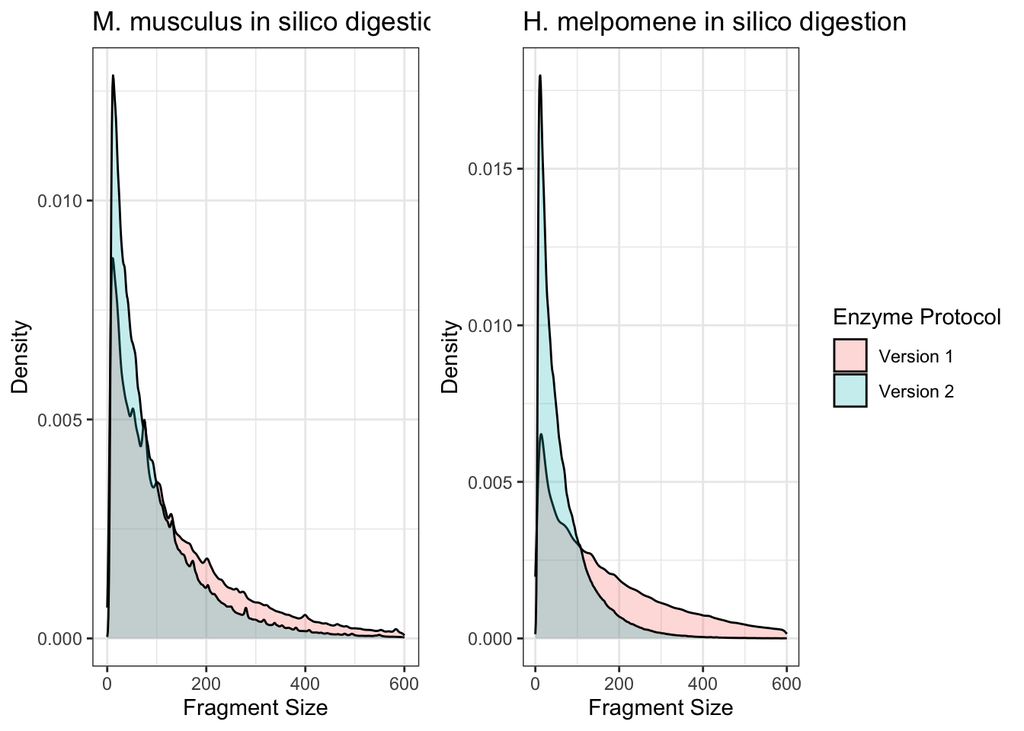

```r
#Construct ggplot density plots of data with species side-by-side (easier to read and understand.)
hmm_fraglen <- ggplot(melted_hmm, aes(x = value, fill = variable)) +
  geom_density(alpha = 0.25) + xlim(0,600) + ggtitle("H. melpomene in silico digestion") +
  xlab("Fragment Size") + ylab("Density")  + theme_bw() + scale_fill_discrete(name = "Enzyme Protocol", labels = c("Version 1", "Version 2"))
m39_fraglen <- ggplot(melted_m39, aes(x = value, fill = variable)) +
  geom_density(alpha = 0.25) + xlim(0,600) + ggtitle("M. musculus in silico digestion") +
  xlab("Fragment Size") + ylab("Density") + theme_bw() + guides(fill="none")

#visualize graphs
plot_grid(m39_fraglen, hmm_fraglen, rel_widths = c(1.45,2))
```

## Prioritized follow-up studies

To follow up on this, I will actually perform the experiment on the butterfly samples using the version 1 protocol, since I learned that fewer <20bp fragments will be lost in that protocol (which intuitively makes sense given the enzymes used). I will also evaluate the efficiency of using those restriction enzymes by examining the actual distribution of fragment lengths on a gel relative to what I expected from the in silico digestion to see if there is suboptimal digestion.